# miMeta Tutorial for Melody

Zhoujingpeng Wei

Department of Biostatistics and Medical Informatics, University of Wisconsin-Madison

zwei74@wisc.edu

2025-07-31

#### Package

miMeta 1.1.0

# 1 Introduction

`miMeta` is a R package and it implements the new methods for meta-analysis of microbiome association studies that respect the unique features of microbiome data such as compositionality. This tutorial gives examples of applying a meta-analysis method called Melody [1] for microbial signature selection. Melody first generates summary statistics for each study and then uses the summary statistics across studies to select microbial signatures.

# 2 Installation

Install package from GitHub.

```r
if(!require("miMeta", quietly = TRUE)){
  devtools::install_github("ZjpWei/miMeta")
}
```

Load the packages.

```r
library("miMeta")
library("tidyverse")
```

# 3 Meta-analysis given all samples of all participating studies

There are two approaches miMeta can run meta-analysis.

Approach #1: If the individual-level sample data across all participating studies are available, the function `melody` can take these data as input to generate, harmonize, and combine summary association statistics across studies for accurate and robust identification of microbial signatures.

Approach #2: If individual-level samples of each study are not in a central place, summary statistics can be generated for each study separately using the functions `melody.null.model` and `melody.get.summary`. The summary statistics can be transported to a central place to be harmonized and combined for signature selection using the function `melody.meta.summary`.

We demonstrate Approach #1 in this session and Approach #2 in the next session.

Here we use the datasets from two metagenomics studies of colorectal cancer (CRC) [2] to demonstrate the use of each function. The `CRC_abd` is a list of sample-by-feature matrices of relative abundance counts of 267 species under order *Clostridiales* from the two studies. The `CRC_meta` is a data frame including the sample-level variables from these two studies. In particular, the following variables are in the `CRC_meta` data:

- Sample identity: “Sample_ID”
- Study name: “Study”
- Disease status: “Group”

```r
data("CRC_data")
CRC_abd <- CRC_data$CRC_abd
CRC_meta <- CRC_data$CRC_meta
```

```r
# Prepare input data
rel.abd <- list()
covariate.interest <- list()
for(d in c("FR-CRC", "DE-CRC")){
  rel.abd[[d]] <- CRC_abd[CRC_meta$Sample_ID[CRC_meta$Study == d],]
  disease <- as.numeric(CRC_meta$Group[CRC_meta$Study == d] == "CRC")
  names(disease) <- CRC_meta$Sample_ID[CRC_meta$Study == d]
  covariate.interest[[d]] <- data.frame(disease = disease)
}

meta.result <- melody(rel.abd = rel.abd, covariate.interest = covariate.interest,
                      ref = "Coprococcus catus [ref_mOTU_v2_4874]", verbose = TRUE)
```

```
## ++ Construct summary statistics. ++
```

```
## ++ Construct summary statistics for study FR-CRC and covariate of interest disease. ++
```

```
## ++ Construct summary statistics for study DE-CRC and covariate of interest disease. ++
```

```
## ++ Search for the best model for covariate of interest disease. ++
```

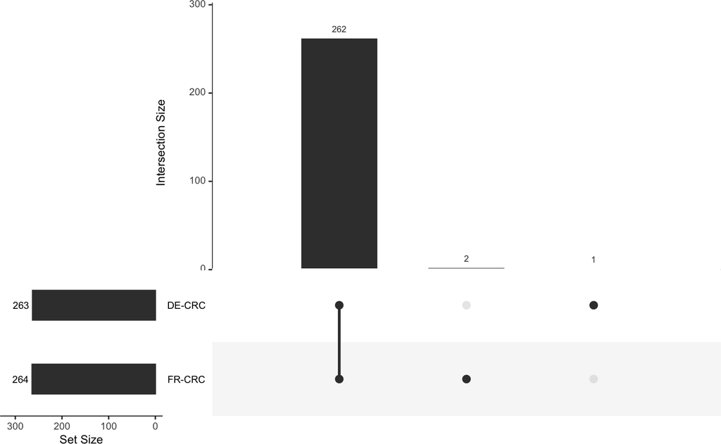

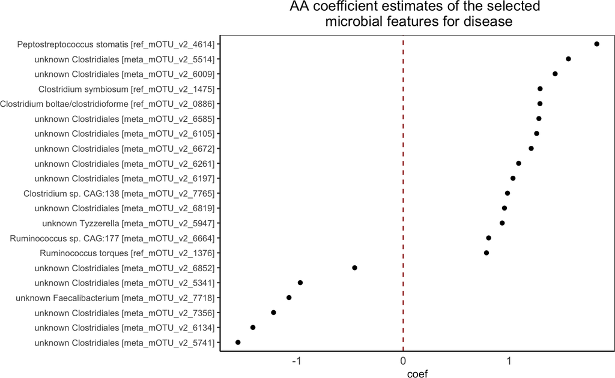

The following shows 20 coefficient estimates of the microbial features in the best model (the features with non-zero coefficients are the selected signatures):

```r
head(data.frame(coef = meta.result$disease$coef), n = 20)
```

```
##                                                          coef
## Anaerostipes caccae [ref_mOTU_v2_1381]                0.00000
## Anaerostipes hadrus [ref_mOTU_v2_1309]                0.00000
## Anaerotruncus colihominis [ref_mOTU_v2_0884]          0.00000
## Blautia hydrogenotrophica [ref_mOTU_v2_4324]          0.00000
## Blautia obeum [ref_mOTU_v2_4202]                      0.00000
## Blautia obeum [ref_mOTU_v2_4719]                      0.00000
## Blautia producta [ref_mOTU_v2_4020]                   0.00000
## Blautia sp. KLE 1732 [ref_mOTU_v2_0859]               0.00000
## Blautia wexlerae [ref_mOTU_v2_0466]                   0.00000
## butyrate-producing bacterium SS3/4 [ref_mOTU_v2_3825] 0.00000
## Butyrivibrio crossotus [ref_mOTU_v2_4383]             0.00000
## Clostridiales bacterium VE202-14 [ref_mOTU_v2_2689]   0.00000
## Clostridium asparagiforme [ref_mOTU_v2_4394]          0.00000
## Clostridium boltae/clostridioforme [ref_mOTU_v2_0886] 1.28966
## Clostridium citroniae [ref_mOTU_v2_4882]              0.00000
## Clostridium clostridioforme [ref_mOTU_v2_0979]        0.00000
## Clostridium leptum [ref_mOTU_v2_4234]                 0.00000
## Clostridium saccharolyticum [ref_mOTU_v2_1380]        0.00000
## Clostridium scindens [ref_mOTU_v2_0883]               0.00000
## Clostridium sp. AT4 [meta_mOTU_v2_7263]               0.00000
```

By default, Melody only outputs the information about the best model. If users want to see the information about all models on the search path of subset size, set output.best.one = FALSE. See help(melody) for more details.

# 4 Meta-analysis given samples of one study at a time

If the datasets of different studies live in different locations and cannot be conveniently shared among studies, we can first generate summary statistics for each study:

```r
# Generate summary statistics for each study
null.obj.FR <- melody.null.model(rel.abd = rel.abd["FR-CRC"], ref = "Coprococcus catus [ref_mOTU_v2_4874]")
summary.stats.FR <- melody.get.summary(null.obj = null.obj.FR,
                                       covariate.interest = covariate.interest["FR-CRC"])

null.obj.DE <- melody.null.model(rel.abd = rel.abd["DE-CRC"], ref = "Coprococcus catus [ref_mOTU_v2_4874]")
summary.stats.DE <- melody.get.summary(null.obj = null.obj.DE,
                                       covariate.interest = covariate.interest["DE-CRC"])
```

These summary statistics can be transported to a central location for meta-analysis:

```r
# Concatenate summary statistics
summary.stats.all <- c(summary.stats.FR, summary.stats.DE)
```

```r
# Meta-analysis to harmonize and combine summary statistics across studies
meta.result.2 <- melody.meta.summary(summary.stats = summary.stats.all, verbose = TRUE)
```

```
## ++ Search for the best model for covariate of interest disease. ++
```

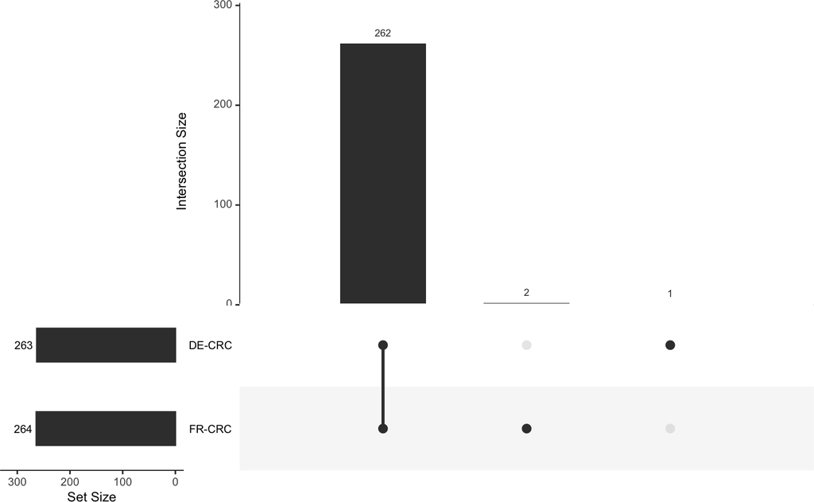

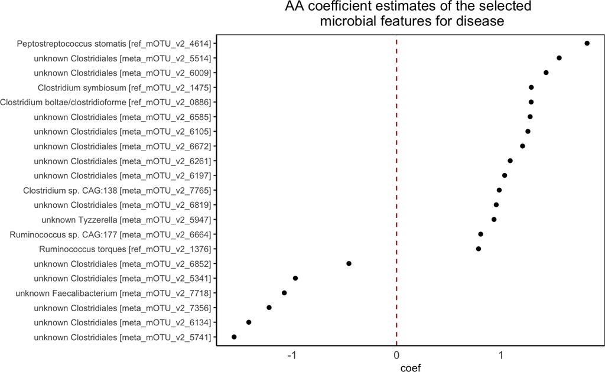

The meta-analysis results generated this way are identical to those generated in the previous session.

# 5 Meta-analysis of large-scale association scan

Microbiome association studies can involve a large number of covariates of interest (e.g., omics variables). We show here how to use Melody to meta-analyze eight microbiome-metabolome association studies [3]. In these eight studies, we have 101 genera and 450 metabolites and we are interested in identifying genera that are associated with individual metabolites. This analysis takes approximately 20 minutes.

```r
# Load metabolite data:
# You may see the following website on how to directly load data from
# github into R https://github.com/ZjpWei/Melody/raw/main/Metabolite.rda
load(file = url("https://github.com/ZjpWei/Melody/raw/main/Metabolite.rda"))

# Change genura names
for(d in names(otu_data_lst)){
  colnames(otu_data_lst[[d]]) <-  gsub(".*;g__", "", colnames(otu_data_lst[[d]]))
}

# Get null model
null.obj <- melody.null.model(rel.abd = otu_data_lst, covariate.adjust = covariates_adjust_lst)

# Get summary statistics
summary.stats <- melody.get.summary(null.obj = null.obj, covariate.interest = cmpd_data_lst, cluster = cluster_data_lst)

# Meta-analysis
meta.scan.result <- melody.meta.summary(summary.stats = summary.stats, verbose = TRUE)
```

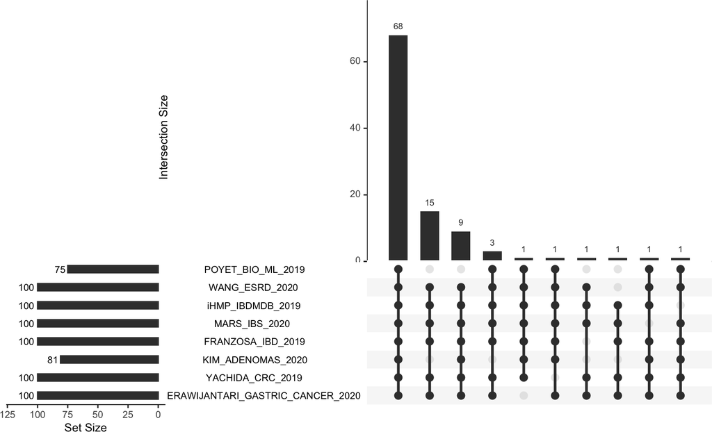

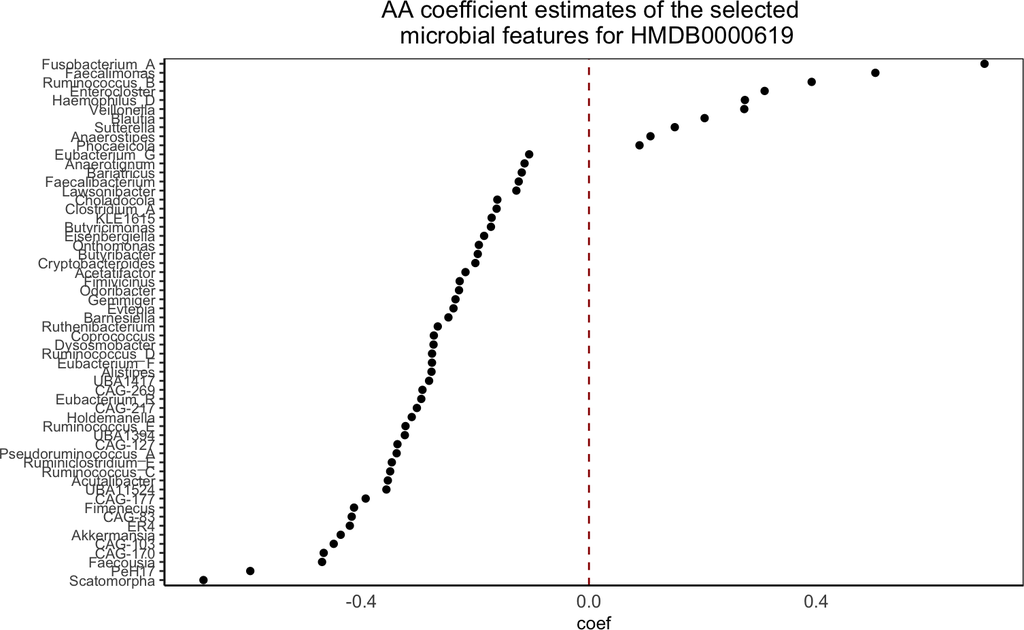

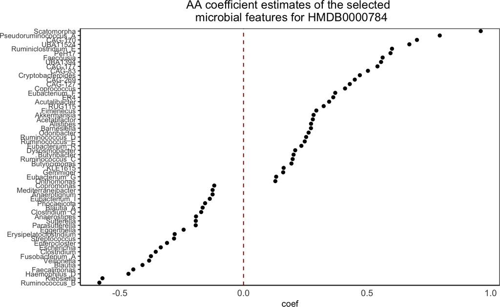

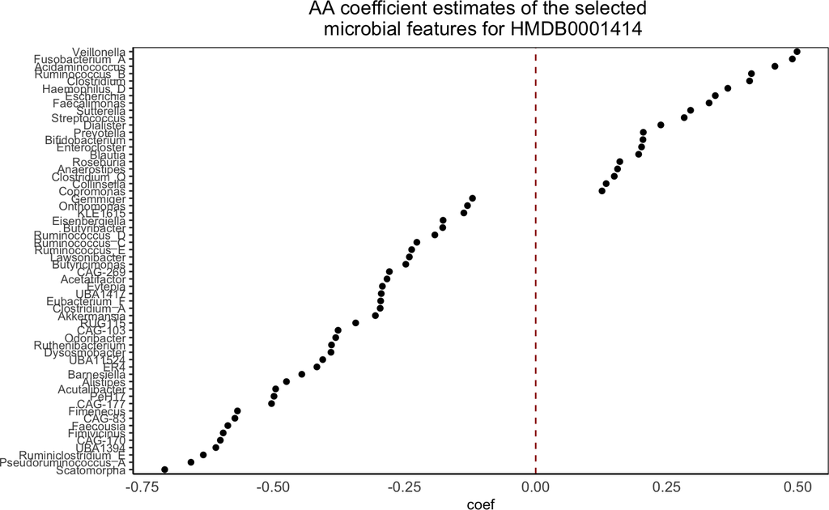

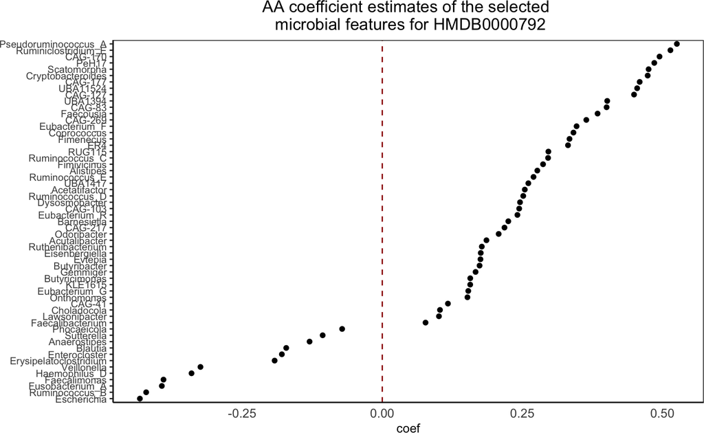

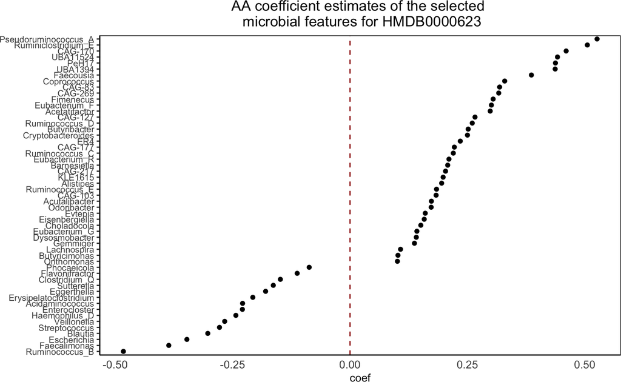

The following shows 20 coefficient estimates of the microbial features for 5 metabolites.

```r
selected.num <- sort(unlist(lapply(meta.scan.result, function(d){sum(d$coef!=0)})), decreasing = TRUE)
top.cov.name <- names(selected.num)[1:min(5, length(selected.num))]
coef_mat <- sapply(meta.scan.result[top.cov.name], function(d){d$coef}, simplify = TRUE)
rownames(coef_mat) <- gsub(".*;g__","g__",rownames(coef_mat))
head(coef_mat, n = 20)
```

```
##                 HMDB0000619 HMDB0000784 HMDB0001414 HMDB0000792 HMDB0000623
## Acetatifactor    -0.2172211   0.2804254  -0.2835135   0.2543737   0.2985871
## Acidaminococcus   0.0000000   0.0000000   0.4561328   0.0000000  -0.2287934
## Acutalibacter    -0.3537872   0.3463894  -0.4958773   0.1859421   0.1733028
## Agathobacter      0.0000000   0.0000000   0.0000000   0.0000000   0.0000000
## Agathobaculum     0.0000000   0.0000000   0.0000000   0.0000000   0.0000000
## Akkermansia      -0.4366937   0.2834183  -0.3056866   0.0000000   0.0000000
## Alistipes        -0.2769928   0.2731956  -0.4752360   0.2767597   0.1951420
## Alloprevotella    0.0000000   0.0000000   0.0000000   0.0000000   0.0000000
## Anaerobutyricum   0.0000000   0.0000000   0.0000000   0.0000000   0.0000000
## Anaerostipes      0.1081830  -0.1921712   0.1560324  -0.1297960   0.0000000
## Anaerotignum     -0.1133036  -0.1251361   0.0000000   0.0000000   0.0000000
## Bacteroides       0.0000000   0.0000000   0.0000000   0.0000000   0.0000000
## Bariatricus      -0.1182175   0.0000000   0.0000000   0.0000000   0.0000000
## Barnesiella      -0.2472429   0.2728205  -0.4459775   0.2249714   0.2080257
## Bifidobacterium   0.0000000   0.0000000   0.2045159   0.0000000   0.0000000
## Bilophila         0.0000000   0.0000000   0.0000000   0.0000000   0.0000000
## Blautia           0.2034051  -0.4087724   0.1963087  -0.1714706  -0.3028904
## Blautia_A         0.0000000  -0.1653551   0.0000000   0.0000000   0.0000000
## Butyribacter     -0.1955944   0.2024720  -0.1772769   0.1736443   0.2516645
## Butyricimonas    -0.1724562   0.1938733  -0.2477097   0.1570374   0.1021319
```

# 7 Reference

1. Wei Z, Chen G, Tang ZZ. Melody: Meta-analysis of Microbiome Association Studies for Discovering Generalizable Microbial Signatures. Submitted.
2. Wirbel, Jakob et al. Meta-analysis of fecal metagenomes reveals global microbial signatures that are specific for colorectal cancer.
3. Muller, E., Algavi, Y.M. & Borenstein, E. The gut microbiome-metabolome dataset collection: a curated resource for integrative meta-analysis. npj Biofilms Microbiomes 8, 79 (2022).